# Twitter_Analysis

Shuyi Jiang

12/17/2017

# Twitter Analysis: Canada Goose

Living in Boston where is usually decorated in white (snow) for about 5 months, I really need to get armed to survive the winter. The temperature and wind get me into a fan of Canada Goose parka. My “Mystique”, the over-knee down jacket from Canada Goose, with the highest warmth level, is the warmest jacket I have ever owned. It is my source of confidence to get out in snowy day in Boston. I was quite happy to see a flagship store was under construction in prudential center and was looking forwards to stopping by after it opened. However, on November 24th, the day this flagship store was relased to the public, I witnessed a protest against Canada Goose for being cruelt to animals, such as coyote. I am curious about what others think about that. Since twitter is a very popular social media platform where people express their thoughts, I decided to feed my curiosity starting from twitter.

```
## [1] "Using direct authentication"
```

# When do people tweet?

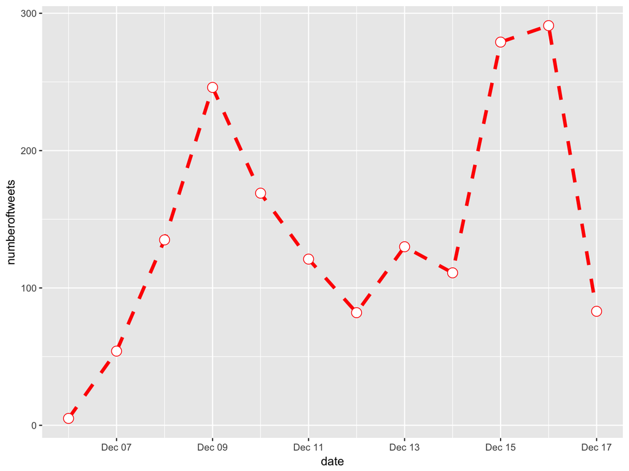

People are more likely to tweet at weekend.

# Map: Where people tweet

```
## 8403 tweets have been parsed.
```

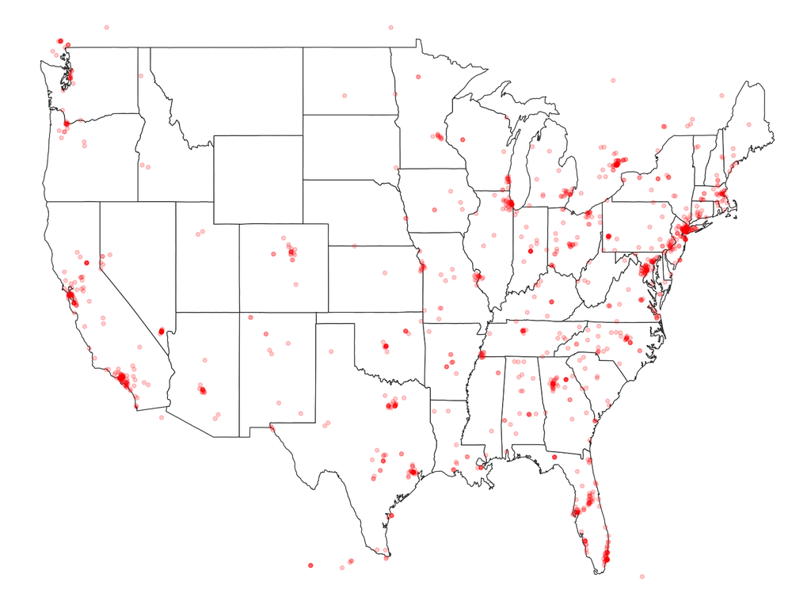

# Word Frequency

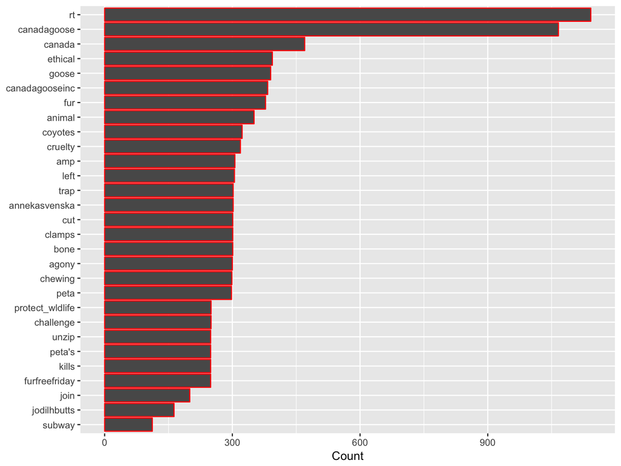

I looked into the top words mentioned in tweets relevant to Canada Goose. Words refer to animal abuse, such as “ethical”, “animal” and “coyotes” are the most popular.

# Word Cloud

Here is the word cloud for the top words in tweets.

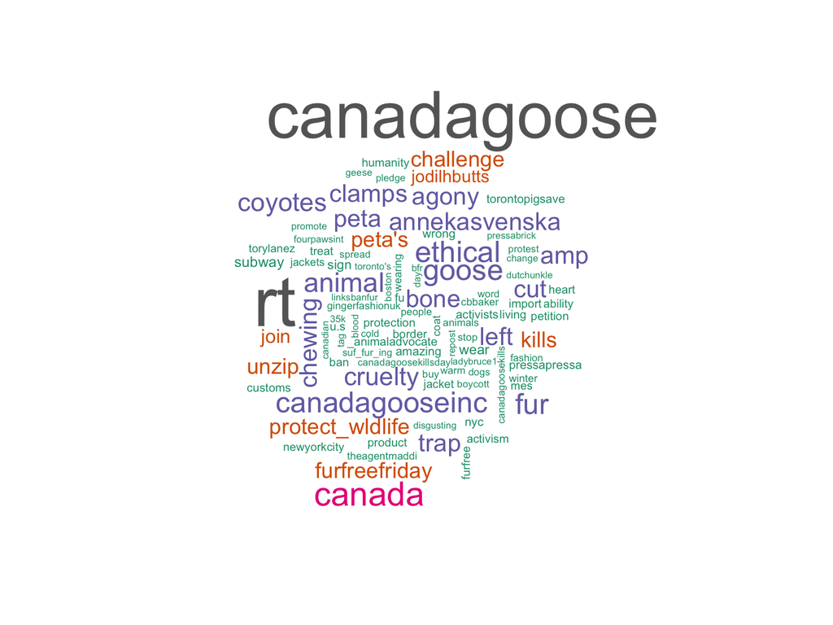

```
## # A tibble: 27,314 x 4
##           word sentiment lexicon score
##          <chr>     <chr>   <chr> <int>
##  1      abacus     trust     nrc    NA
##  2     abandon      fear     nrc    NA
##  3     abandon  negative     nrc    NA
##  4     abandon   sadness     nrc    NA
##  5   abandoned     anger     nrc    NA
##  6   abandoned      fear     nrc    NA
##  7   abandoned  negative     nrc    NA
##  8   abandoned   sadness     nrc    NA
##  9 abandonment     anger     nrc    NA
## 10 abandonment      fear     nrc    NA
## # ... with 27,304 more rows
```

```
## # A tibble: 2,476 x 2
##          word score
##         <chr> <int>
##  1    abandon    -2
##  2  abandoned    -2
##  3   abandons    -2
##  4   abducted    -2
##  5  abduction    -2
##  6 abductions    -2
##  7      abhor    -3
##  8   abhorred    -3
##  9  abhorrent    -3
## 10     abhors    -3
## # ... with 2,466 more rows
```

```
## # A tibble: 6,788 x 2
##           word sentiment
##          <chr>     <chr>
##  1     2-faced  negative
##  2     2-faces  negative
##  3          a+  positive
##  4    abnormal  negative
##  5     abolish  negative
##  6  abominable  negative
##  7  abominably  negative
##  8   abominate  negative
##  9 abomination  negative
## 10       abort  negative
## # ... with 6,778 more rows
```

```
## # A tibble: 13,901 x 2
##           word sentiment
##          <chr>     <chr>
##  1      abacus     trust
##  2     abandon      fear
##  3     abandon  negative
##  4     abandon   sadness
##  5   abandoned     anger
##  6   abandoned      fear
##  7   abandoned  negative
##  8   abandoned   sadness
##  9 abandonment     anger
## 10 abandonment      fear
## # ... with 13,891 more rows
```

# Sentiments

I am intereted in what kinds of attitude people have when they tweet. Therefore, I analysize the sentiments of words people use in there tweets.

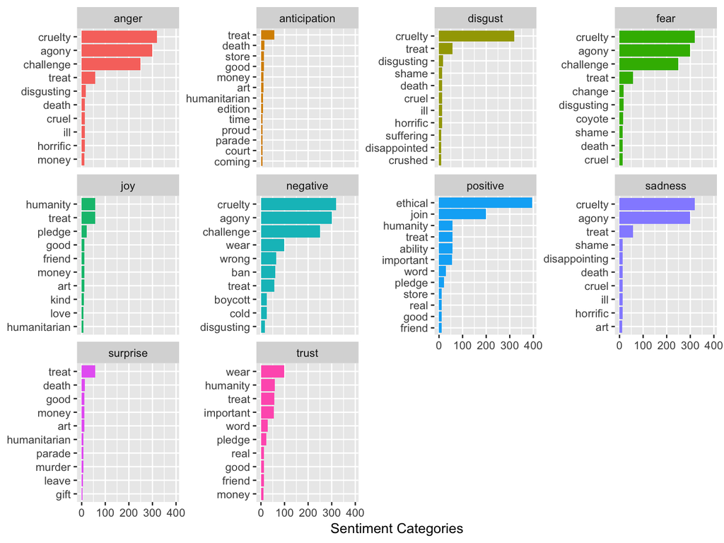

# Posivite VS Negative

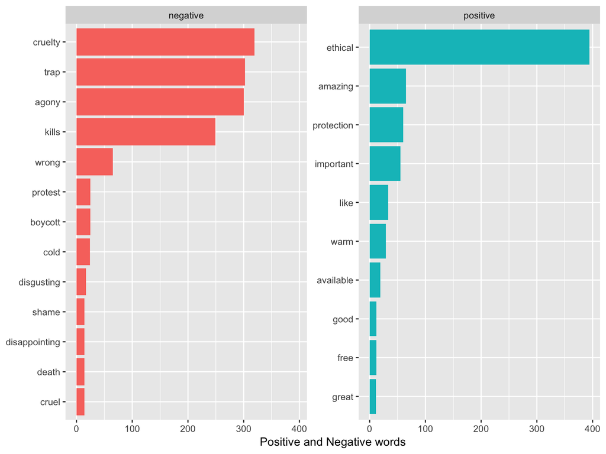

The plots indicates that people who have negative opinion speak louder online.

# Comparison Cloud

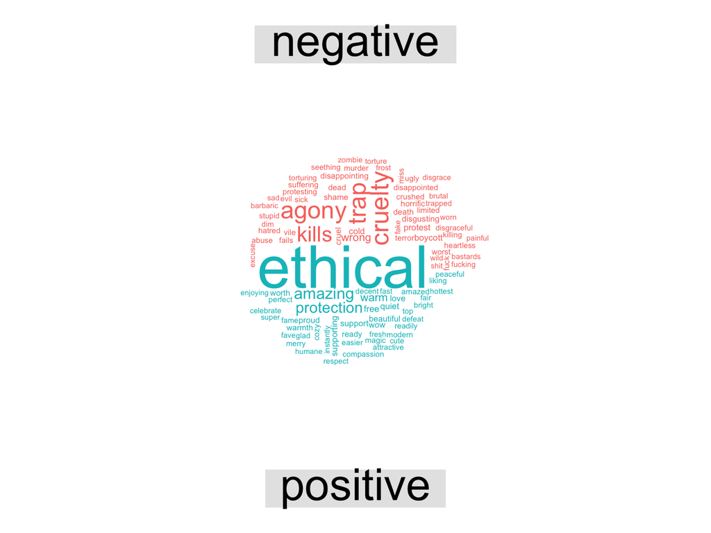

People against Canada Goose and would like to take a boycott are more active online.

# Attitude

| sentiment | count |
| --- | --- |
| negative | 124 |
| positive | 97 |

# Statistics Summary

```
##      word            sentiment               n
##  Length:221         Length:221         Min.   :  1.00
##  Class :character   Class :character   1st Qu.:  1.00
##  Mode  :character   Mode  :character   Median :  2.00
##                                        Mean   : 11.87
##                                        3rd Qu.:  5.00
##                                        Max.   :394.00
```

# Top Words

| word | sentiment | n |
| --- | --- | --- |
| ethical | positive | 394 |
| cruelty | negative | 319 |
| trap | negative | 302 |
| agony | negative | 300 |
| kills | negative | 249 |
| amazing | positive | 65 |
| wrong | negative | 65 |
| protection | positive | 60 |
| important | positive | 55 |
| like | positive | 33 |
| warm | positive | 29 |
| boycott | negative | 25 |
| protest | negative | 25 |
| cold | negative | 24 |
| available | positive | 19 |
| disgusting | negative | 17 |
| cruel | negative | 14 |
| death | negative | 14 |
| disappointing | negative | 14 |
| shame | negative | 14 |
| horrific | negative | 13 |

# Conclusion

The results indicates that more people are not happy with Canada Goose because of using real fur. However, what I can see in my real life is the popularity of Canada Goose parka is getting more and more popular, especailly on campus. Twitter might not be a good source to see whether the majority is holding positive or negative opinion. A survey might be a better choice since there are organizations, such as PETA, trying so hard to express and spread their idea against Canada Goose on social medium.